# Analyzing Global Health Disparities: UNICEF’s Role in Tracking Child Mortality and Life Expectancy

- Show All Code
- Hide All Code
- View Source

Author

Name: Arpitha Benkipura Manjappa | Student ID: A00047887

# 1 Introduction

*Children’s health is a vital indicator of a country’s overall progress.*  
UNICEF data provides insights into how life expectancy and child mortality rates are influenced by economic status health care access combined with geographic location worldwide. Visual research methods provide understanding about how health conditions spread across the world while revealing health inequality patterns.

# 2 Scatterplot of GDP vs Life Expectancy

Figure below illustrates the relationship between a country’s GDP per capita and its average life expectancy. The scatterplot demonstrates a clear positive correlation, indicating that higher national income levels are generally associated with longer life spans. The regression line further emphasizes this trend, suggesting that economic development plays a critical role in improving health outcomes.

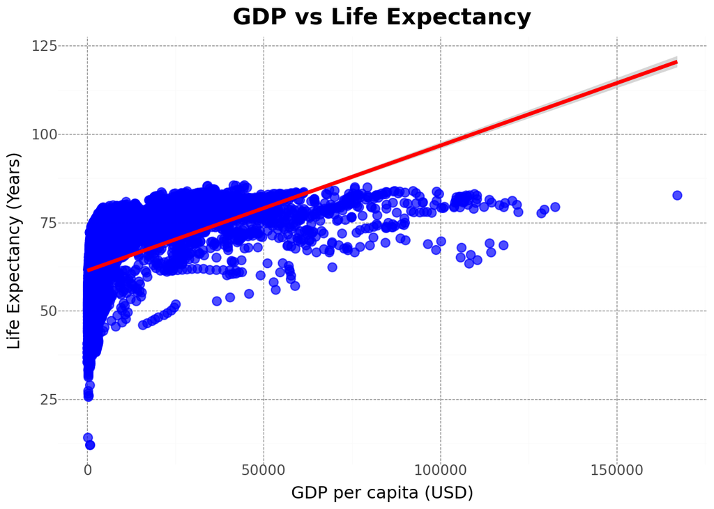

Figure 1: Scatterplot of GDP vs Life Expectancy with Linear Regression Line

```python
# Filter metadata for countries with both GDP and Life Expectancy data
scatter_data = metadata.dropna(subset=["GDP per capita (constant 2015 US$)", "Life expectancy at birth, total (years)"])

# Create scatterplot showing relationship between GDP and Life Expectancy
# This figure illustrates how higher GDP is generally associated with longer life expectancy
scatter_plot = (
    p9.ggplot(scatter_data, p9.aes(x="GDP per capita (constant 2015 US$)", y="Life expectancy at birth, total (years)")) +
    p9.geom_point(color="blue", alpha=0.7, size=3) +  # Data points
    p9.geom_smooth(method="lm", color="red", size=1.5) +  # Regression line
    p9.theme_minimal() +
    p9.theme(
        plot_title=p9.element_text(size=16, face="bold"),
        axis_title=p9.element_text(size=12),
        axis_text=p9.element_text(size=10),
        panel_grid_major=p9.element_line(color="gray", linetype="--", size=0.5)
    ) +
    p9.labs(
        title="GDP vs Life Expectancy",
        x="GDP per capita (USD)",
        y="Life Expectancy (Years)"
    )
)

scatter_plot
```

# 3 Line Chart Showing Global Child Mortality Trend Over Time

The figure below presents a time series analysis of global child mortality rates. The chart highlights a consistent decline over the years, reflecting progress in public health interventions, access to healthcare, and maternal-child services. Despite this positive trend, disparities may still exist among regions.

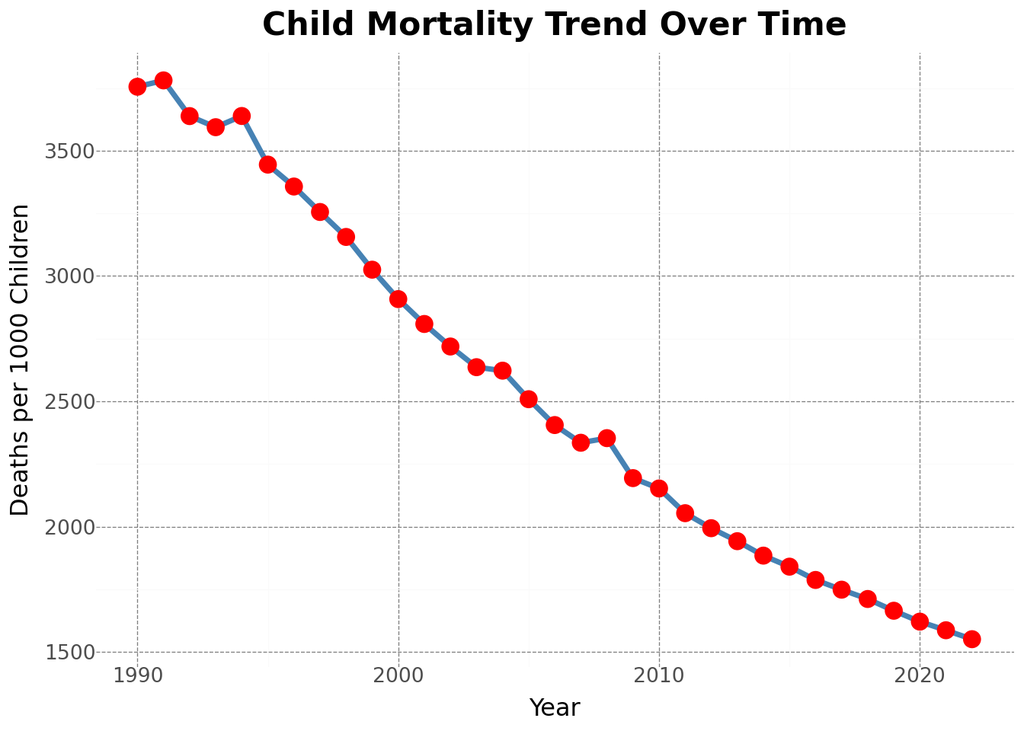

Figure 2: Line Chart Showing Global Child Mortality Trend Over Time

```python
# Group child mortality data by year and compute average global value
child_mortality_trend = child_mortality.groupby("time_period")["obs_value"].mean().reset_index()

# Plot time series of child mortality rates to show progress over the years
# This figure reveals the steady decline in child deaths globally over time
time_series = (
    p9.ggplot(child_mortality_trend, p9.aes(x="time_period", y="obs_value")) +
    p9.geom_line(color="steelblue", size=1.5) +  # Line chart
    p9.geom_point(color="red", size=4) +  # Highlight data points
    p9.theme_minimal() +
    p9.theme(
        plot_title=p9.element_text(size=16, face="bold"),
        axis_title=p9.element_text(size=12),
        axis_text=p9.element_text(size=10),
        panel_grid_major=p9.element_line(color="gray", linetype="--", size=0.5)
    ) +
    p9.labs(
        title="Child Mortality Trend Over Time",
        x="Year",
        y="Deaths per 1000 Children"
    )
)

time_series
```

# 4 Bar Chart of Top 20 Countries with Highest Life Expectancy

The figure below shows the top 20 countries with the highest life expectancy based on the latest available data. These nations tend to be economically developed with robust healthcare systems, higher educational attainment, and better living conditions. The visualization emphasizes the stark contrasts between countries in terms of health equity and longevity.

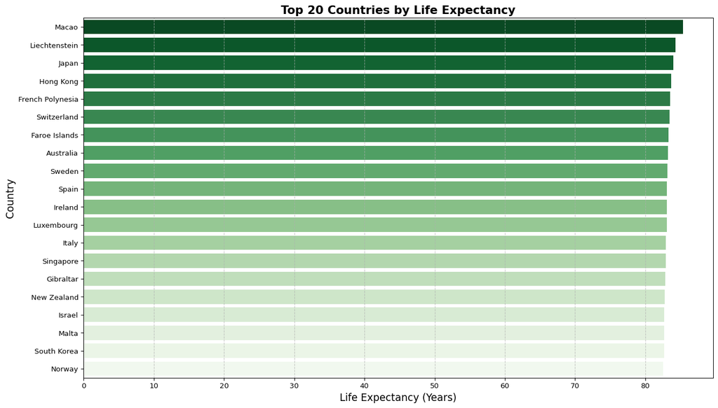

Figure 3: Bar Chart of Top 20 Countries with Highest Life Expectancy

```python
# Extract latest available life expectancy data per country
latest_metadata = metadata.groupby("country").last().reset_index()

# Select top 20 countries with highest life expectancy
top_life_expectancy = latest_metadata.nlargest(20, "Life expectancy at birth, total (years)")

# Bar chart to compare top-performing countries in terms of life span
# This visualization helps highlight where people are living longest and why
plt.figure(figsize=(14, 8))
sns.barplot(
    data=top_life_expectancy,
    x="Life expectancy at birth, total (years)",
    y="country",
    palette="Greens_r",
    errorbar=None
)

plt.xlabel("Life Expectancy (Years)", fontsize=14)
plt.ylabel("Country", fontsize=14)
plt.title("Top 20 Countries by Life Expectancy", fontsize=16, fontweight='bold')
plt.grid(axis="x", linestyle="--", alpha=0.7)
plt.tight_layout()
plt.show()
```

# 5 World Map Visualizing Life Expectancy by Country

The figure below provides a world map visualization of life expectancy by country. Geographic patterns emerge, with countries in North America, Europe, and parts of Asia displaying higher life expectancy, while many African nations show lower figures. This spatial representation helps identify regional disparities and health inequities on a global scale.

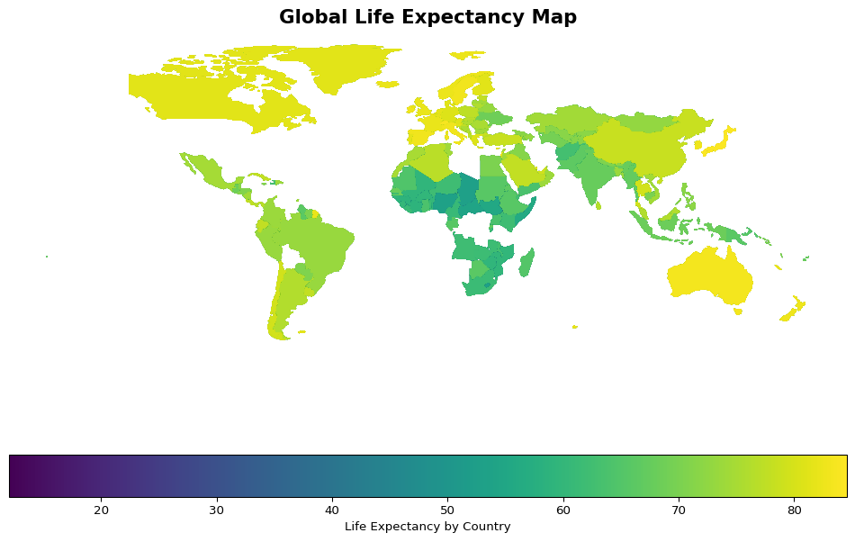

Figure 4: World Map Visualizing Life Expectancy by Country

```python
# Load world shapefile and merge with life expectancy data
world = gpd.read_file(r"D:\Arpitha_College\SEM-1\BAA 1030\Quarto_assignment\110m_cultural\ne_110m_admin_0_countries.shp")
world = world.merge(metadata, left_on="SOVEREIGNT", right_on="country", how="left")

# Create a choropleth map of life expectancy by country
# This figure reveals global geographic patterns in life expectancy and highlights regional disparities
world.plot(
    column="Life expectancy at birth, total (years)",
    legend=True,
    legend_kwds={'label': "Life Expectancy by Country", 'orientation': "horizontal"},
    figsize=(10, 8)
)

plt.title("Global Life Expectancy Map", fontsize=16, fontweight='bold')
plt.axis("off")
plt.tight_layout()
plt.show()
```